# Työnteko työttömyysturvan aikana kannustavammaksi

Antti J. Tanskanen, Elinkeinoelämän keskusliitto EK

14.9.2018

Työttömyysturvan ansiosidonnainen päiväraha maksetaan soviteltuna, mikäli työtön työskentelee työttömyysturvan aikana. Sovitellun päivärahan maksamisella on tiettyjä reunaehtoja, kuten se että työaika saa olla korkeintaan 80 prosenttiä alan täydestä työajasta.

Myös etuuden taso yhteensovitetaan ansiotulon kanssa: soviteltu päiväraha ja palkka eivät saa yhteensä ylittää nk. vakiintunutta ansiota. Tämä on perusteltua, koska ilman tällaista rajoitusta työtön saattaisi olla jopa paremmassa asemassa työttömyyden aikana kuin ennen työttömyyttä. Ylärajan laskutavasta kuitenkin seuraa tilanteita, joissa lisätyöskentely voi johtaa pienempään käteenjäävään tuloon [Viitamäki, 2015]. Seuraavassa analysoidaan tätä hieman huolellisemmin.

Tässä keskitytään ansiosidonnaiseen päivärahaan, työmarkkinatukea tai peruspäivärahaa ei erikseen analysoida. Lapsikorotuksia tai korotettua ansiosidonnaista työttömyysturvaa ei erikseen huomioida, mutta ne on käsiteltävissä suoraviivaisilla parametrimuutoksilla.

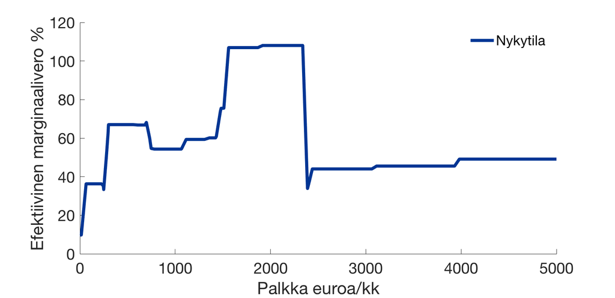

# 1 Soviteltu päiväraha

Ansiosidonnaisen työttömyysturvan soviteltu päiväraha $E$ voidaan esittää muodossa
$$E(s)=P+\alpha\max(0,\min(V,C)-P)+\beta\max(0,V-C)-\frac{1}{2}\max(0,s-A),$$
missä $P$ on perusturva 696,60 e/kk (ilman lapsikorotuksia), $s$ on työttömyyden aikainen palkkatulo. Korvaustaso taitetta $C=3078$ e/kk pienemmällä vakiintuneella ansiotasolla $V$ on $\alpha=0.45$. Korvaustaso taitteen $C$ ylittävältä osalta vakiintuneesta ansiosta $V$ on $\beta=0.20$. Parametri $A$ kuvaa suojaosaa 300 e/kk, minä verran työttömyyden aikana saa työskennellä ilman että sillä on vaikutusta työttömyysturvaa.

Merkitään vakiintunutta ansiota ilman prosenttivähennystä $W$, jolloin prosenttivähennetty vakiintunut ansio on $V=(1-\gamma)W$, missä $\gamma$ on prosenttivähennys (4,48% vuonna 2018). Ansiosidonnaisen työttömyysturvan perusteena on prosenttivähennetty vakiintunut ansio $V$, millä on haluttu turvata se, ettei työttömyyskorvaus ole anteliaampi kuin henkilön palkka, josta maksetaan sosiaaliturvamaksuja. Tällöin työttömyyskorvauksen ja palkan suhde ei riipu sosiaaliturvamaksuista.

Ylärajan työttömyysturvalle muodostaa se, että etuus yhdessä työttömyysaikaisen palkan kanssa ei ylitä (prosenttivähennettyä) vakiintunutta ansiota
$$E(s)+s\leq V.$$
Ylärajan soveltamisessa ei erikseen huomioida työtulon suojaosaa.

# 2 Ylärajan soveltaminen

## 2.1 Alle taitteen

Koska työansio-osasta menee prosenttivähennystä suuremmat palkansaajan maksut (mm P-TEL), nousee leikkauskohdan yläpuolella välillä $(s_L,V)$ efektiivinen marginaaliveroprosentti yli sadan [Viitamäki, 2015].

Jos työttömyydenaikainen ansio on alle suojaosan, $0\leq s\leq A$, on etuus
$$E(s)=P+\alpha(V-P)$$
ja leikkauskohta
$$s_L=(1-\alpha)(V-P)$$
Ylärajasääntö tulee sovellettavaksi alle suojaosan olevilla tuloilla vain kun vakiintunut ansio on lähellä peruspäivärahan tasoa.

## 2.2 Taitteen yläpuolella

Yllä tarkasteltiin ylärajan vaikutusta taitetta $C$ pienemmillä vakiintuneilla ansiotasoilla. Tarkastellaan seuraavaksi päivärahan ylärajan vaikutusta taitteen yläpuolella.

Kun $V\geq C$ ja $V\geq s\geq A$ on etuus muotoa
$$E(s)=P+\alpha(C-P)+\beta(V-C)-\frac{1}{2}(s-A),$$
ja lyhyellä laskulla nähdään, että leikkauskohta $s_L$ on
$$s_L=2((1-\beta)V-(1-\alpha)P-(\alpha-\beta)C)-A.$$

Myös taitteen yläpuolella ylärajan soveltamisalue laajenee, jos perusosaa $P$ kasvatetaan tai suojaosaa $A$ nostetaan.

## 2.3 Ylärajasäännön soveltamisalue

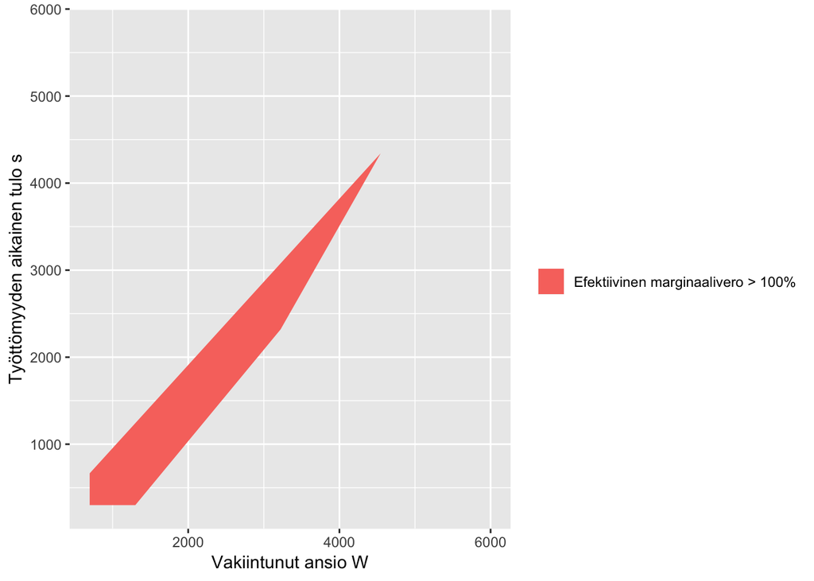

Kuva 2. Kannustamaton alue vakiintuneen ansion funktiona.

Tällöin peruspäivärahan vaikutus lakkaa. Ilman sitä ja työtulon suojaosaa ei kannustamatonta aluetta syntyisi lainkaan.

# 3 Vaihtoehtoinen ylärajamalli

Ylärajasta ei ole mahdollista luopua ilman että työskentely työttömyysturvan aikana voisi muodostua kannattavammaksi kuin täysiaikainen työskentely. Kannustavuuden kannalta parasta olisi, jos jokainen myös työttömyyden aikana ansaittu euro kasvattaisi käteenjäävää tuloa. Nyt tilanne ei ole tämä.

Ehkä selkein malli olisi sellainen, jossa etuus menee nollille kun työttömyyden aikaiset tulot ohittava vakiintuneen ansiotason. Yksi tällainen ylärajamalli on
$$E(s)\leq \mu(W-s)$$
missä $\mu$ on vakio. Mallissa työttömyysetuus on aina korkeintaan $\mu$ prosenttia (prosenttivähentämättömän) vakiintuneen ansion $W$ ja työttömyydenaikaisten ansioiden $s$ erotuksesta.

Käytännössä $\mu$:n taso määrittelisi suurelta osin efektiivisen marginaaliveron sillä alueella missä kattosääntö vaikuttaisi, jolloin matala $\mu$ johtaisi matalaan efektiiviseen marginaaliveroasteeseen ja korkea $\mu$ taas korkeaan. Toisaalta matala $\mu$ johtaisi leveään kattosäännön soveltamisalueeseen ja korkea kapeampan soveltamisalueeseen. Kuva 3 näyttää esimerkin siitä, miten vaihtoehtoinen ylärajamalli vaikuttaa efektiiviseen marginaaliveroasteeseen.

Jo nyt sovelletaan ansiosidonnaiseen työttömyysturvaan ehtoa, että etuus saa olla korkeintaan 90 prosenttia (prosenttivähennetystä) vakiintuneesta ansiotasosta
$$E(s)\leq 0.9V=0.8597W$$
Tämä yhdistyisi ylärajasääntöön, jos $\mu=0.86$, jolloin työttömyysturvan säännöstö hienoisesti yksinkertaistuisi.

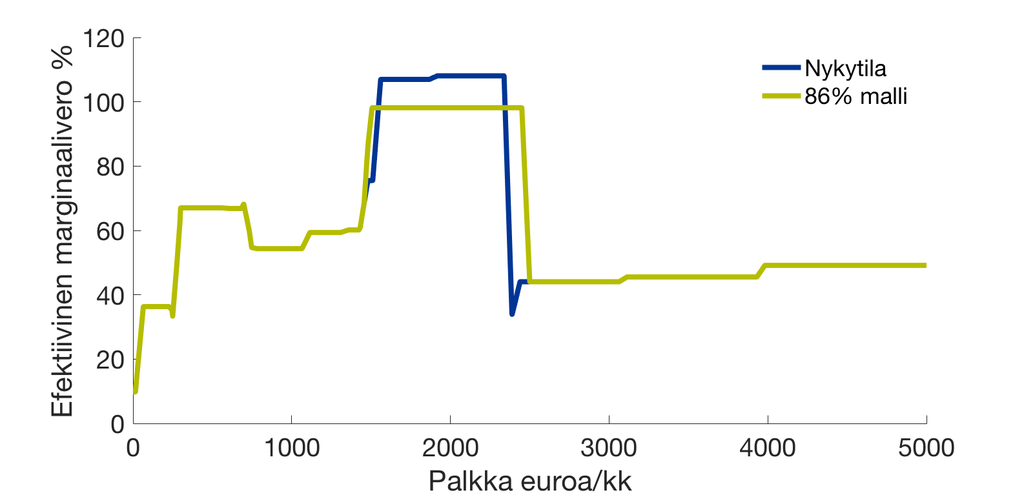

## 3.1 Yläraja vaihtoehdossa

Jos $C\geq V \geq P$ ja $V\geq s\geq A$, on leikkauspiste $s_L$, jonka yläpuolella yläraja leikkaa etuutta
$$s_L=\frac{(1-\alpha)P+(\alpha-\alpha\gamma-\mu)W+0.5A}{0.5-\mu}$$

Kun $s\leq A$, on E(s)
$$s_L=\frac{1}{\mu}(\mu-\alpha)W-(1-\alpha)P)$$

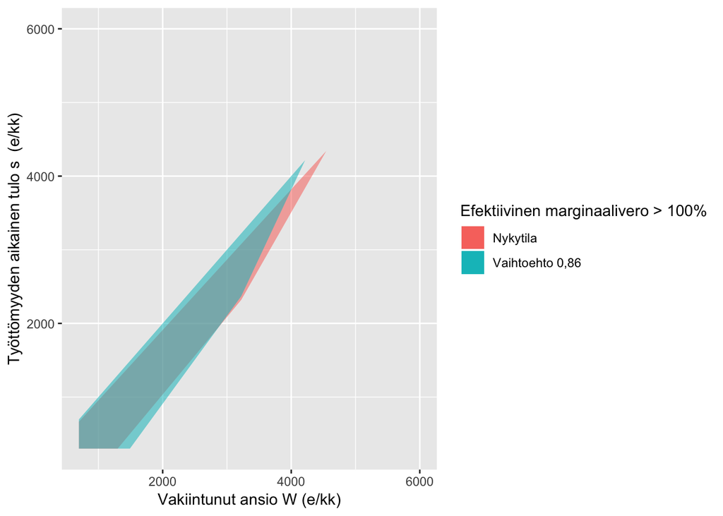

Kuva 4. Kannustamaton alue nykymallissa verrattuna vaihtoehtoiseen ylärajaan.

Jos $V\geq C$ ja $V\geq s\geq A$, on
$$s_L=\frac{0.5A+(1-\alpha)P+(\alpha-\beta)C-(\beta-\beta\gamma-\mu)W}{0.5-\mu}$$

Ylärajaa sovellattaisiin $\mu=0.86$ -mallissa lähes identtisellä alueella kuin nykymallia. Vaikka tällä alueella efektiivinen marginaalivero olisi lähes 100 %, parantaisi malli selvästi nykytilaa, jossa ylärajan soveltamisalueella efektiivinen marginaaliveroaste on yli 100 %.

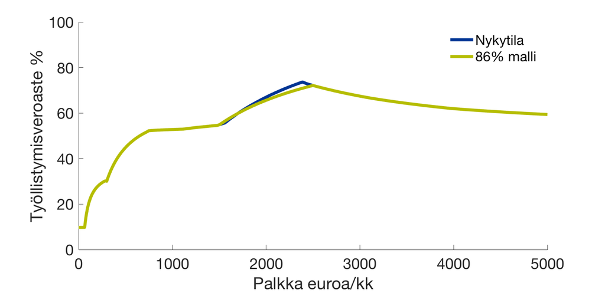

Kuva 5. Esimerkki työllistymisveroasteesta marginaaliverosta yksinasuvalle ansiosidonnaista työttömyyturvaa saavalle. Kuvassa nykymallia verrataan 86% vaihtoehtoiseen ylärajamalliin. Vakiintunut ansio 2 500 e/kk.

# 4 SISU-laskelma

Sisulla tehdyssä staattisessa laskelmassa kustannusvaikutus on 1,9 me kustannuksia aleneva. Tämä ei huomioi dynaamisia vaikutuksia, mutta joka tapauksessa vaikutukset kokonaiskustannuksiin lienevät pienet. Muutos lienee kustannusneutraali.

# 5 Johtopäätökset

Nykyinen ansiosidonnaisen työttömyysturvan sinänsä hyvin perusteltu ylärajasääntö aiheuttaa soviteltuun työttömyysturvaan kannustavuusongelman. Tilannetta olisi mahdollista parantaa melko yksinkertaisella ylärajasäännön muokkaamisella, joka myös johtaisi siihen että työttömyysturvan kaksi ylärajasääntöä korvattaisiin yhdellä säännöllä. Vaihtoehtoisen ylärajasäännön kustannusvaikutuksen voi arvioida vähäiseksi, joten muutos vaikuttaa perustellulta.

# 6 Viittaukset

Viitamäki, H. Työnteon kannustimet - mitä jää käteen?, VATT Muistiot 50, 2015.